# GFCR Indicator Visualizations

F1 - F7 and raw finance data

Author

Iain R. Caldwell

Published

May 30, 2025

## Context - Displaying and visualizing GFCR indicators

This GFCR report shows how a convening agent can export their GFCR data from a MERMAID project (www.datamermaid.org), display the monitoring & evaluation indicators as tables, and turn indicator data into useful visualizations. This code shows the first seven indicators and the raw finance data. Including the raw finance data allows a convening agent to aggregate it however they find most useful.

## Load package libraries and set parameters

This section loads package libraries and assigns parameters used in the rest of the code.

```r
rm(list = ls()) #remove past stored objects
options(scipen = 999) #turn off scientific notation

####  Load packages and libraries ####
## If this is the first time using mermaidr, install the package through "remotes"
# install.packages("remotes")
# remotes::install_github("data-mermaid/mermaidr")
library(mermaidr) #package to download data from datamermaid.org
library(tidyverse) #package that makes it easier to work with data
library(ggplot2)
#devtools::install_github("liamgilbey/ggwaffle") #Only needs to be run once
library(ggwaffle)
library(emojifont)
library(ggpubr)
library(kableExtra)
library(waffle)
library(ggpattern)
library(ggfortify)
library(purrr)
library(stringr)

#### Assign parameters ####
dataColors <- c("#475853", "#d88a3b", "#498FC9")
names(dataColors) <- c("Baseline", "Target", "Report")
```

## Load data from a GFCR project

Here is an example of how GFCR data can be exported from a MERMAID project using the mermaidr package (https://data-mermaid.github.io/mermaidr/). For this example we will focus on the MERMAID project called “MAR+Invest”.

```r
### Find example projects called "MAR+Invest" that is tagged as "GFCR"
gfcrProject <- mermaid_search_projects(name = "MAR+Invest",
                                       tags = "GFCR",
                                       include_test_projects = F)

### Get all GFCR data associated with that project ####
gfcrProjectReports <- mermaid_get_gfcr_report(project = gfcrProject)
```

## Reports in project

The following table shows the GFCR reports that are currently included in this project.

```r
projectReportsTBL <- gfcrProjectReports$F1 %>%
  select(Project, Title, `Reporting Date`, `Data Type`) %>%
  mutate(`Reporting Date` = as.Date(`Reporting Date`)) %>%
  arrange(`Reporting Date`)

# Identify the earliest "Report" date and mark as "Baseline"
if (any(projectReportsTBL$`Data Type` == "Report", na.rm = TRUE)) {
  earliest_date <-
    min(projectReportsTBL$`Reporting Date`[projectReportsTBL$`Data Type` == "Report"],
        na.rm = TRUE)
  projectReportsTBL <- projectReportsTBL %>%
    mutate(ColorType = ifelse(`Data Type` == "Report" &
                                `Reporting Date` == earliest_date,
                              "Baseline",
                              `Data Type`))
}

# Get row indices for each ColorType
baseline_rows <- which(projectReportsTBL$ColorType == "Baseline")
target_rows <- which(projectReportsTBL$ColorType == "Target")
report_rows <- which(projectReportsTBL$ColorType == "Report")

# Create kable table with color styling
kable(projectReportsTBL %>% select(-ColorType)) %>%
  kable_styling(full_width = FALSE, position = "left") %>%
  row_spec(baseline_rows, background = dataColors["Baseline"], color = "white") %>%
  row_spec(target_rows, background = dataColors["Target"]) %>%
  row_spec(report_rows, background = dataColors["Report"])
```

| Project | Title | Reporting Date | Data Type |
| --- | --- | --- | --- |
| MAR+Invest | Baseline | 2022-07-13 | Report |
| MAR+Invest | Phase 1 Target | 2023-07-13 | Target |
| MAR+Invest | Mid year Report | 2024-07-31 | Report |
| MAR+Invest | End year Report | 2024-12-31 | Report |
| MAR+Invest | Mid Term Target | 2027-07-13 | Target |
| MAR+Invest | Final Target | 2030-07-13 | Target |

## F1. Coral Reef extent of GFCR project

```r
f1TableTrans <- gfcrProjectReports$F1 %>%
  arrange(`Reporting Date`) %>%
  mutate(Label = ifelse(`Reporting Date` == earliest_date &
                          `Data Type` == "Report",
                        paste0(`Reporting Date`, " Baseline"),
                        paste0(`Reporting Date`, " ", `Data Type`))) %>%
  select(Label, `Area (km2)`) %>%
  column_to_rownames(var = "Label") %>%
  sjmisc::rotate_df()

rownames(f1TableTrans) <- unique(gfcrProjectReports$F1$`Sub-Indicator Name`)

kable(f1TableTrans) %>%
  kable_styling(full_width = T, position = "left") %>%
  kableExtra::column_spec(1, bold = TRUE) %>%
  kableExtra::column_spec(baseline_rows+1,
                          background = dataColors["Baseline"], color = "white") %>%
  kableExtra::column_spec(target_rows+1,
                          background = dataColors["Target"],
                          border_right = TRUE,
                          extra_css = "border-right: 1px solid black;") %>%
  kableExtra::column_spec(report_rows+1,
                          background = dataColors["Report"],
                          border_right = TRUE,
                          extra_css = "border-right: 1px solid black;")
```

|  | 2022-07-13 Baseline | 2023-07-13 Target | 2024-07-31 Report | 2024-12-31 Report | 2027-07-13 Target | 2030-07-13 Target |
| --- | --- | --- | --- | --- | --- | --- |
| Total area of coral reefs in GFCR Programme (sq.km) | 0 | 696.12 | 581.147 | 581.15 | 696.12 | 696.12 |

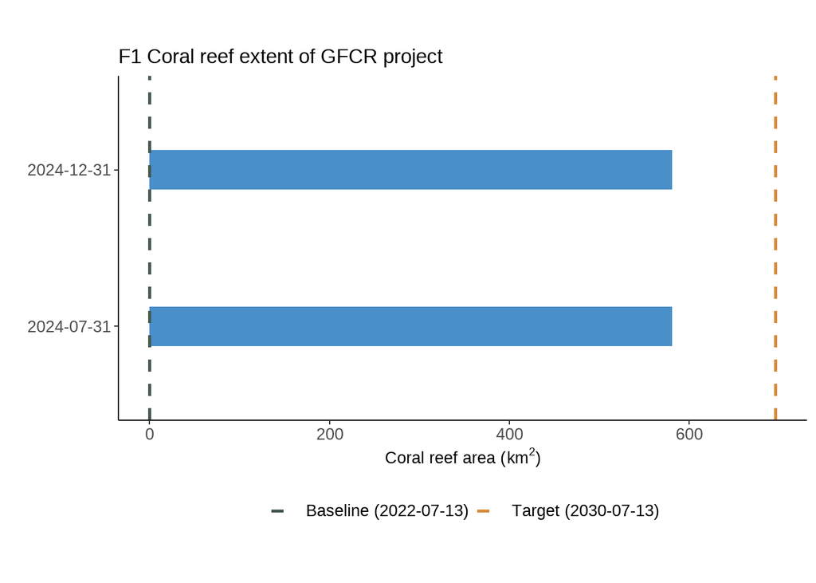

```r
#Show the baseline and last target as dashed lines
#Show all the reports as horizontal barplots
gfcrIndF1PlotTBL <- gfcrProjectReports$F1 %>%
  filter(`Data Type` == "Report") %>%
  bind_rows(gfcrProjectReports$F1 %>%
              filter(`Data Type` == "Target") %>%
              filter(`Reporting Date` == max(`Reporting Date`))) %>%
  mutate(Color = ifelse(`Reporting Date` == earliest_date &
                          `Data Type` == "Report",
                        "Baseline",
                        `Data Type`)) %>%
  mutate(Color = factor(Color, levels = c("Baseline", "Target", "Report")),
         `Data Type` = factor(`Data Type`, levels = c("Target", "Report")),
         `Reporting Date` = factor(`Reporting Date`),
         Label = paste0(Color, " (", `Reporting Date`, ")"))

dataLabels = gfcrIndF1PlotTBL$Label
names(dataLabels) <- gfcrIndF1PlotTBL$Color

ggplot() +
  geom_col(data = gfcrIndF1PlotTBL %>%
             filter(Color == "Report"),
           aes(x = `Reporting Date`, y = `Area (km2)`, fill = Color),
           width = 0.25) +
  geom_hline(data = gfcrIndF1PlotTBL %>%
               filter(Color != "Report"),
             aes(yintercept = `Area (km2)`, color = Color),
             linetype = "dashed",
             linewidth = 1) +
  labs(x = "",
       y = expression(paste("Coral reef area ( ",km^2,")")),
       title = "F1 Coral reef extent of GFCR project") +
  scale_fill_manual(values = dataColors) +
  scale_color_manual(values = dataColors, labels = dataLabels) +
  guides(fill = "none") +
  theme(aspect.ratio = 0.5,
        plot.title = element_text(hjust = 0, size = 25),
        panel.background = element_rect(fill = "white"),
        legend.title = element_blank(),
        legend.position = "bottom",
        axis.title = element_text(size = 20),
        axis.text = element_text(size = 20),
        legend.text = element_text(size = 20),
        axis.line = element_line(colour = "black")) +
  coord_flip()
```

## F2. Area of coral reefs under conservation and sustainable management

```r
f2TableTrans <- gfcrProjectReports$F2 %>%
  mutate(Label =
           ifelse(`Reporting Date` == min(gfcrProjectReports$F2$`Reporting Date`),
                  paste0(`Reporting Date`, " Baseline"),
                  paste0(`Reporting Date`, " ", `Data Type`))) %>%
  pivot_wider(names_from = `Sub-Indicator Name`,
              values_from = `Area (km2)`) %>%
  select(Label, starts_with("F2")) %>%
  column_to_rownames(var = "Label") %>%
  sjmisc::rotate_df()

kable(f2TableTrans) %>%
  kable_styling(full_width = F, position = "left") %>%
  kableExtra::column_spec(1, bold = TRUE) %>%
  kableExtra::column_spec(baseline_rows+1,
                          background = dataColors["Baseline"], color = "white") %>%
  kableExtra::column_spec(target_rows+1,
                          background = dataColors["Target"],
                          border_right = TRUE,
                          extra_css = "border-right: 1px solid black;") %>%
  kableExtra::column_spec(report_rows+1,
                          background = dataColors["Report"],
                          border_right = TRUE,
                          extra_css = "border-right: 1px solid black;")
```

|  | 2022-07-13 Baseline | 2023-07-13 Target | 2024-07-31 Report | 2024-12-31 Report | 2027-07-13 Target | 2030-07-13 Target |
| --- | --- | --- | --- | --- | --- | --- |
| F2.1a Area of MPAs and OECMs (as aligned to GBF Target 3) [coralreef] (sq.km) | 696.12 | 696.12 | 696.12 | 696.12 | 696.12 | 696.12 |
| F2.1b Area of MPAs and OECMs (as aligned to GBF Target 3) [total] (sq.km) | 0.00 | 0.00 | 21448.70 | 21448.70 | 0.00 | 0.00 |
| F2.2a Area of locally managed areas / co-managed areas [coralreef] (sq.km) | 0.00 | 0.00 | 0.00 | 0.00 | 0.00 | 0.00 |
| F2.2b Area of locally managed areas / co-managed areas [total] (sq.km) | 0.00 | 0.00 | 0.00 | 0.00 | 0.00 | 0.00 |
| F2.3a Area of fisheries management [coralreef] (sq.km) | 0.00 | 0.00 | 158.55 | 158.55 | 158.55 | 158.50 |
| F2.3b Area of fisheries management [total] (sq.km) | 0.00 | 158.55 | 8686.16 | 8686.16 | 0.00 | 8686.00 |
| F2.4 Area with pollution mitigation (sq.km) | 0.00 | 185.82 | 59.49 | 59.49 | 185.00 | 185.00 |
| F2.5: Area of non-coral reef ecosystems, e.g., mangroves, seagrass or other associated ecosystems (sq.km) | 0.00 | 0.00 | 0.00 | 2054.55 | 0.00 | 0.00 |

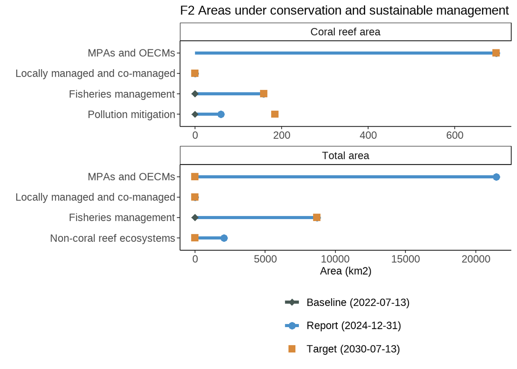

```r
#Create plots for the areas using only the most recent data for report
gfcrIndF2PlotTBL <- gfcrProjectReports$F2 %>%
  filter(`Data Type` == "Report") %>%
  filter(`Reporting Date` == min(`Reporting Date`)|
           `Reporting Date` == max(`Reporting Date`)) %>%
  bind_rows(gfcrProjectReports$F2 %>%
              filter(`Data Type` == "Target") %>%
              filter(`Reporting Date` == max(`Reporting Date`))) %>%
  mutate(Color = ifelse(`Reporting Date` == min(`Reporting Date`),
                        "Baseline",
                        `Data Type`)) %>%
  mutate(Color = factor(Color, levels = c("Baseline", "Target", "Report")),
         `Data Type` = factor(`Data Type`, levels = c("Target", "Report")),
         `Reporting Date` = factor(`Reporting Date`),
         Label = paste0(Color, " (", `Reporting Date`, ")")) %>%
  mutate(CoralOrTotal =
           case_when(grepl(pattern = "F2.1a|F2.2a|F2.3a|F2.4",
                           x = `Sub-Indicator Name`) ~ "Coral reef area",
                     grepl(pattern = "F2.1b|F2.2b|F2.3b|F2.5",
                           x = `Sub-Indicator Name`) ~ "Total area"),
         ProtectionType =
           case_when(grepl(pattern = "F2.1",
                           x = `Sub-Indicator Name`) ~
                       "MPAs and OECMs",
                     grepl(pattern = "F2.2",
                           x = `Sub-Indicator Name`) ~
                       "Locally managed and co-managed",
                     grepl(pattern = "F2.3",
                           x = `Sub-Indicator Name`) ~
                       "Fisheries management",
                     grepl(pattern = "F2.4",
                           x = `Sub-Indicator Name`) ~
                       "Pollution mitigation",
                     grepl(pattern = "F2.5",
                           x = `Sub-Indicator Name`) ~
                       "Non-coral reef ecosystems")) %>%
  mutate(ProtectionType =
           factor(ProtectionType,
                  levels = c("MPAs and OECMs",
                             "Locally managed and co-managed",
                             "Fisheries management",
                             "Pollution mitigation",
                             "Non-coral reef ecosystems")))

pointShapes <- c("Baseline" = 18,  # Diamond
                 "Report" = 19,    # Circle
                 "Target" = 15)    # Square

ggplot() +
  facet_wrap(~CoralOrTotal, ncol=1, scales = "free") +
  geom_segment(data = gfcrIndF2PlotTBL %>% filter(`Data Type` == "Report"),
               aes(x = `Area (km2)`,
                   xend = 0,
                   y = ProtectionType,
                   yend = ProtectionType,
                   colour = Color),
               linewidth = 1.5) +
  geom_point(data = gfcrIndF2PlotTBL,
             aes(x = `Area (km2)`,
                 y = ProtectionType,
                 colour = Color,
                 shape = Color),
             size = 3) +
  labs(y = "",
       title = "F2 Areas under conservation and sustainable management") +
  scale_y_discrete(limits = rev) +
  scale_color_manual(values = dataColors, labels = dataLabels) +
  scale_shape_manual(values = pointShapes, labels = dataLabels) +
  guides(color = guide_legend(override.aes = list(shape = pointShapes),
                              nrow = 3),
         shape = "none") +
  theme(plot.title = element_text(hjust = 0, size = 25),
        panel.background = element_rect(fill = "white"),
        legend.title = element_blank(),
        legend.position = "bottom",
        axis.title = element_text(size = 20),
        axis.text = element_text(size = 20),
        legend.text = element_text(size = 20),
        strip.background = element_rect(fill = "white", colour = "black"),
        strip.text = element_text(size = 20),
        axis.line = element_line(colour = "black"))
```

## F3. Area of coral reefs under effective coral restoration

```r
#Create a table with subindicators as rows
f3TableTrans <- gfcrProjectReports$F3 %>%
  mutate(Label =
           ifelse(`Reporting Date` == min(gfcrProjectReports$F3$`Reporting Date`),
                  paste0(`Reporting Date`, " Baseline"),
                  paste0(`Reporting Date`, " ", `Data Type`))) %>%
  pivot_wider(names_from = `Sub-Indicator Name`,
              values_from = Value) %>%
  select(Label, starts_with("F3")) %>%
  column_to_rownames(var = "Label") %>%
  sjmisc::rotate_df()

kable(f3TableTrans) %>%
  kable_styling(full_width = F, position = "left") %>%
  kableExtra::column_spec(1, bold = TRUE) %>%
  kableExtra::column_spec(baseline_rows+1,
                          background = dataColors["Baseline"],
                          color = "white") %>%
  kableExtra::column_spec(target_rows+1,
                          background = dataColors["Target"],
                          border_right = TRUE,
                          extra_css = "border-right: 1px solid black;") %>%
  kableExtra::column_spec(report_rows+1,
                          background = dataColors["Report"],
                          border_right = TRUE,
                          extra_css = "border-right: 1px solid black;")
```

|  | 2022-07-13 Baseline | 2023-07-13 Target | 2024-07-31 Report | 2024-12-31 Report | 2027-07-13 Target | 2030-07-13 Target |
| --- | --- | --- | --- | --- | --- | --- |
| F3.1 Area of effective coral reef restoration (sq.km) | 0 | 0 | 0 | 0.01 | 0.01 | 0.04 |
| F3.2 Number of in situ coral reef restoration projects | 0 | 0 | 4 | 4.00 | 4.00 | 4.00 |
| F3.3 Number of coral reef restoration plans, technologies, strategies or guidelines developed | 0 | 2 | 2 | 4.00 | 2.00 | 2.00 |
| F3.4 Number of coral reef restoration trainings | 0 | 0 | 0 | 0.00 | 0.00 | 0.00 |
| F3.5a Number of people engaged in coral reef restoration [men] | 0 | 7 | 4 | 6.00 | 10.00 | 13.00 |
| F3.5b Number of people engaged in coral reef restoration [women] | 5 | 6 | 9 | 11.00 | 13.00 | 13.00 |
| F3.5c Number of people engaged in coral reef restoration [youth] | 0 | 0 | 0 | 0.00 | 0.00 | 0.00 |
| F3.5d Number of people engaged in coral reef restoration [indigenous] | 0 | 0 | 0 | 0.00 | 0.00 | 0.00 |
| F3.6 Number of response plans to support coral reef restoration after severe shocks | 1 | 1 | 1 | 1.00 | 1.00 | 1.00 |

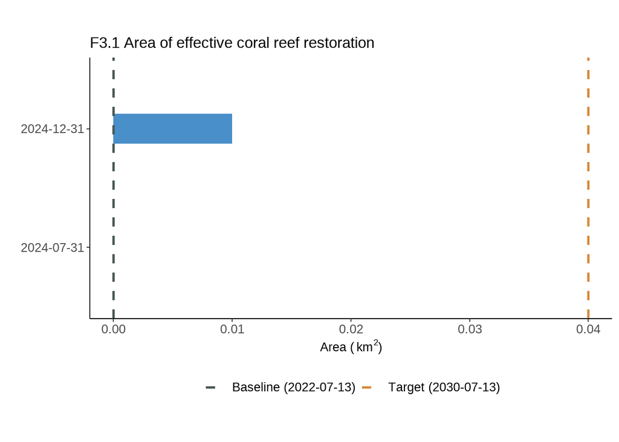

```r
#Plot for F3.1 Area of coral reef restoration
gfcrIndF3_1PlotTBL <- gfcrProjectReports$F3 %>%
  filter(`Data Type` == "Report" &
           grepl(pattern = "F3.1", x = `Sub-Indicator Name`)) %>%
  bind_rows(gfcrProjectReports$F3 %>%
              filter(`Data Type` == "Target" &
                       grepl(pattern = "F3.1", x = `Sub-Indicator Name`)) %>%
              filter(`Reporting Date` == max(`Reporting Date`))) %>%
  mutate(Color = ifelse(`Reporting Date` == earliest_date &
                          `Data Type` == "Report",
                        "Baseline",
                        `Data Type`)) %>%
  mutate(Color = factor(Color, levels = c("Baseline", "Target", "Report")),
         `Data Type` = factor(`Data Type`, levels = c("Target", "Report")),
         `Reporting Date` = factor(`Reporting Date`),
         Label = paste0(Color, " (", `Reporting Date`, ")"))

dataLabels = gfcrIndF3_1PlotTBL$Label
names(dataLabels) <- gfcrIndF3_1PlotTBL$Color

ggplot() +
  geom_col(data = gfcrIndF3_1PlotTBL %>%
             filter(Color == "Report"),
           aes(x = `Reporting Date`, y = Value, fill = Color),
           width = 0.25) +
  geom_hline(data = gfcrIndF3_1PlotTBL %>%
               filter(Color != "Report"),
             aes(yintercept = Value, color = Color),
             linetype = "dashed",
             linewidth = 1) +
  labs(x = "",
       y = expression(paste("Area ( ",km^2,")")),
       title = "F3.1 Area of effective coral reef restoration") +
  scale_fill_manual(values = dataColors) +
  scale_color_manual(values = dataColors, labels = dataLabels) +
  guides(fill = "none") +
  theme(aspect.ratio = 0.5,
        plot.title = element_text(hjust = 0, size = 25),
        panel.background = element_rect(fill = "white"),
        legend.title = element_blank(),
        legend.position = "bottom",
        axis.title = element_text(size = 20),
        axis.text = element_text(size = 20),
        legend.text = element_text(size = 20),
        axis.line = element_line(colour = "black")) +
  coord_flip()
```

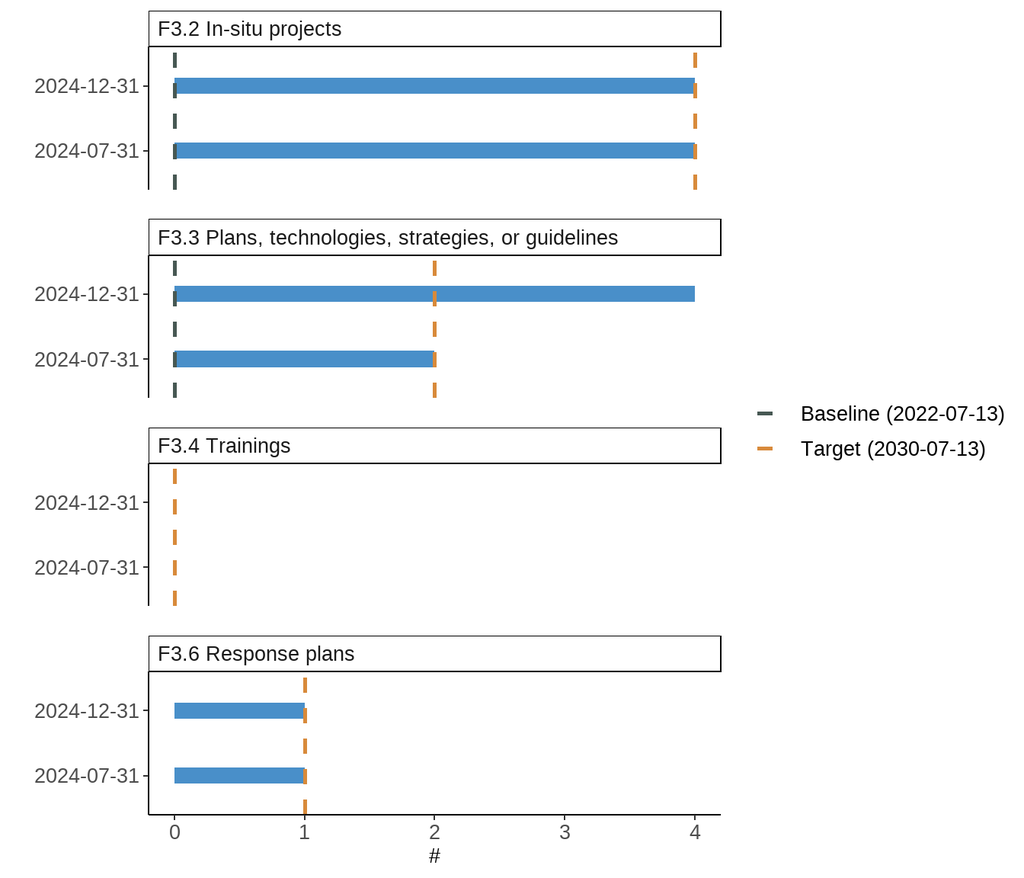

```r
#Plot for sub-indicators with number values - F3.2, F3.3, F3.4, F3.6
gfcrIndF3_2346_PlotTBL <- gfcrProjectReports$F3 %>%
  filter(`Data Type` == "Report" &
           grepl(pattern = "F3.2|F3.3|F3.4|F3.6",
                 x = `Sub-Indicator Name`)) %>%
  bind_rows(gfcrProjectReports$F3 %>%
              filter(`Data Type` == "Target" &
                       grepl(pattern = "F3.2|F3.3|F3.4|F3.6",
                             x = `Sub-Indicator Name`)) %>%
              filter(`Reporting Date` == max(`Reporting Date`))) %>%
  mutate(Color = ifelse(`Reporting Date` == earliest_date &
                          `Data Type` == "Report",
                        "Baseline",
                        `Data Type`)) %>%
  mutate(Color = factor(Color, levels = c("Baseline", "Target", "Report")),
         `Data Type` = factor(`Data Type`, levels = c("Target", "Report")),
         `Reporting Date` = factor(`Reporting Date`),
         Label = paste0(Color, " (", `Reporting Date`, ")"),
         NumberType =
           case_when(grepl(pattern = "F3.2",
                           x = `Sub-Indicator Name`) ~
                       "F3.2 In-situ projects",
                     grepl(pattern = "F3.3",
                           x = `Sub-Indicator Name`) ~
                       "F3.3 Plans, technologies, strategies, or guidelines",
                     grepl(pattern = "F3.4",
                           x = `Sub-Indicator Name`) ~
                       "F3.4 Trainings",
                     grepl(pattern = "F3.6",
                           x = `Sub-Indicator Name`) ~
                       "F3.6 Response plans"))


ggplot() +
  facet_wrap(~NumberType, ncol = 1, scales = "free_y") +
  geom_col(data = gfcrIndF3_2346_PlotTBL %>%
             filter(Color == "Report"),
           aes(x = `Reporting Date`, y = Value, fill = Color),
           width = 0.25) +
  geom_hline(data = gfcrIndF3_2346_PlotTBL %>%
               filter(Color != "Report"),
             aes(yintercept = Value, color = Color),
             linetype = "dashed",
             linewidth = 1) +
  labs(x = "",
       y = "#") +
  scale_y_continuous(breaks = scales::pretty_breaks(n = 5),
                     labels = scales::number_format(accuracy = 1)) +
  scale_fill_manual(values = dataColors) +
  scale_color_manual(values = dataColors, labels = dataLabels) +
  guides(fill = "none") +
  theme(panel.spacing = unit(1, "lines"),
        plot.title = element_text(hjust = 0, size = 25),
        panel.background = element_rect(fill = "white"),
        legend.title = element_blank(),
        legend.position = "right",
        axis.title = element_text(size = 20),
        axis.text = element_text(size = 20),
        legend.text = element_text(size = 20),
        axis.line = element_line(colour = "black"),
        strip.background = element_rect(fill = "white", colour = "black"),
        strip.text = element_text(hjust = 0, size = 20)) +
  coord_flip()
```

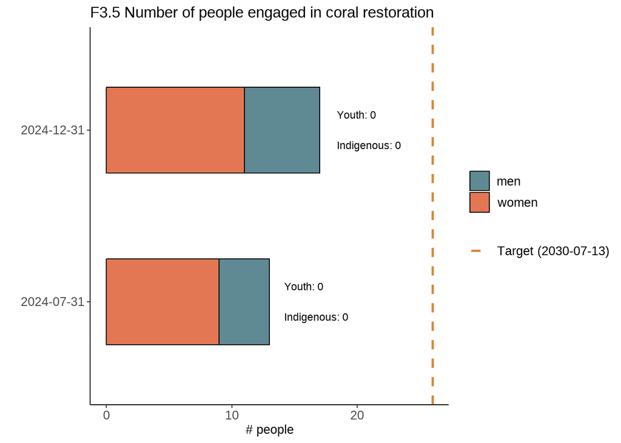

```r
##Stacked bar plot by gender with percentages of youth and indigenous as captions
populationColors <- c("#777777", "#5F8993", "#E37754", "#F6DA80", "#454C84")
names(populationColors) <- c("total", "men", "women", "youth", "indigenous")

# Extract text within brackets to get "men" and "women"
extract_text <- function(s) {
  str_extract(s, "\\[(.*?)\\]") %>%    # Extract text within square brackets
    str_replace_all("\\[|\\]", "")     # Remove brackets
}

# Prepare men/women data
gfcrIndF3_5PlotBarsTBL <- gfcrProjectReports$F3 %>%
  filter(`Data Type` == "Report" &
           grepl(pattern = "F3.5a|F3.5b",
                 x = `Sub-Indicator Name`)) %>%
  filter(`Reporting Date` != min(`Reporting Date`)) %>%
  mutate(`Reporting Date` = factor(`Reporting Date`),
         PopulationType = extract_text(`Sub-Indicator Name`)) %>%
  mutate(PopulationType = factor(PopulationType, levels = c("men", "women")))

# Prepare youth and indigenous data
gfcrIndF3_5OtherTBL <- gfcrProjectReports$F3 %>%
  filter(`Data Type` == "Report",
         grepl("F3.5c|F3.5d", `Sub-Indicator Name`)) %>%
  filter(`Reporting Date` != min(`Reporting Date`)) %>%
  mutate(`Reporting Date` = factor(`Reporting Date`),
         PopulationType = extract_text(`Sub-Indicator Name`)) %>%
  group_by(`Reporting Date`, PopulationType) %>%
  summarise(Value = sum(Value), .groups = "drop") %>%
  pivot_wider(names_from = PopulationType, values_from = Value, values_fill = 0)

# Get total height of each bar (men + women)
bar_totals <- gfcrIndF3_5PlotBarsTBL %>%
  group_by(`Reporting Date`) %>%
  summarise(Total = sum(Value), .groups = "drop")

# Combine totals with youth and indigenous
label_data <- left_join(bar_totals, gfcrIndF3_5OtherTBL, by = "Reporting Date") %>%
  mutate(Label = paste0("Youth: ", youth, "\nIndigenous: ", indigenous))

# Extract target data
gfcrIndF3_5TargetTBL <- gfcrProjectReports$F3 %>%
  filter(`Data Type` == "Target",
         grepl("F3.5a|F3.5b", `Sub-Indicator Name`)) %>%
  group_by(`Reporting Date`, `Data Type`) %>%
  summarise(TargetTotal = sum(Value), .groups = "drop") %>%
  filter(`Reporting Date` == max(`Reporting Date`))

#Horizontal stacked barplots, dashed target, and numbers for youth and indigenous
ggplot(data = gfcrIndF3_5PlotBarsTBL,
       aes(x = `Reporting Date`, y = Value, fill = PopulationType)) +
  geom_col(color = "black", width = 0.5) +
  geom_hline(data = gfcrIndF3_5TargetTBL,
             aes(yintercept = TargetTotal,
                 color = `Data Type`),
             linetype = "dashed",
             linewidth = 1) +
  geom_label(data = label_data,
           aes(x = `Reporting Date`,
               y = Total * 1.05, label = Label),
           inherit.aes = FALSE,
           size = 6, hjust = 0,
           fill = "white",    # Background color
           alpha = 0.6,       # Partial transparency
           label.size = 0,  # Border thickness
           color = "black") +  # Text color
  labs(title = "F3.5 Number of people engaged in coral restoration",
       x = "",
       y = "# people") +
  scale_fill_manual(values = populationColors) +
  scale_color_manual(values = dataColors, labels = dataLabels) +
  theme(plot.title = element_text(hjust = 0, size = 25),
        panel.background = element_rect(fill = "white"),
        legend.title = element_blank(),
        axis.title = element_text(size = 20),
        axis.text = element_text(size = 20),
        legend.text = element_text(size = 20),
        axis.line = element_line(colour = "black"),
        legend.position = "right",
        strip.text = element_text(size = 18),
        strip.background = element_blank()) +
  coord_flip(clip = "off")
```

## F4. Change in coral reef health

```r
#Create a table with subindicators as rows
f4TableTrans <- gfcrProjectReports$F4 %>%
  mutate(Label =
           ifelse(`Reporting Date` == min(gfcrProjectReports$F4$`Reporting Date`),
                  paste0(`Reporting Date`, " Baseline"),
                  paste0(`Reporting Date`, " ", `Data Type`))) %>%
  pivot_wider(names_from = `Sub-Indicator Name`,
              values_from = Value) %>%
  select(Label, starts_with("F4")) %>%
  column_to_rownames(var = "Label") %>%
  sjmisc::rotate_df()

kable(f4TableTrans) %>%
  kable_styling(full_width = F, position = "left") %>%
  kableExtra::column_spec(1, bold = TRUE) %>%
  kableExtra::column_spec(baseline_rows+1,
                          background = dataColors["Baseline"],
                          color = "white") %>%
  kableExtra::column_spec(target_rows+1,
                          background = dataColors["Target"],
                          border_right = TRUE,
                          extra_css = "border-right: 1px solid black;") %>%
  kableExtra::column_spec(report_rows+1,
                          background = dataColors["Report"],
                          border_right = TRUE,
                          extra_css = "border-right: 1px solid black;")
```

|  | 2022-07-13 Baseline | 2023-07-13 Target | 2024-07-31 Report | 2024-12-31 Report | 2027-07-13 Target | 2030-07-13 Target |
| --- | --- | --- | --- | --- | --- | --- |
| F4.1 Average live hard coral cover (%) | 19.0 | 19.0 | 17.0 | 17.0 | 20 | 22.0 |
| F4.2 Average macroalgae cover (%) | 22.0 | 22.0 | 20.0 | 20.0 | 16 | 12.0 |
| F4.3 Average reef fish biomass (kg/ha) | 234.2 | 234.2 | 309.3 | 309.3 | 340 | 395.3 |

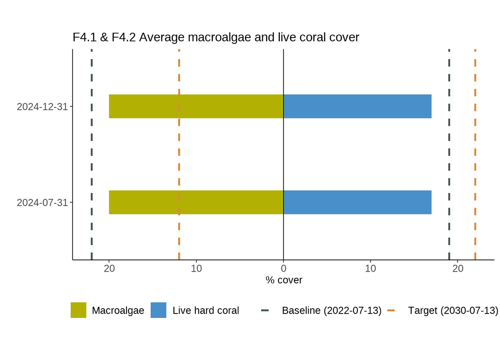

```r
#Barplot showing reported coral and macroalgae on opposite sites of origin
gfcrIndF4_12TBL <- gfcrProjectReports$F4 %>%
  filter(`Data Type` == "Report" &
           !grepl(pattern = "F4.3", x = `Sub-Indicator Name`)) %>%
  bind_rows(gfcrProjectReports$F4 %>%
              filter(`Data Type` == "Target" &
                       !grepl(pattern = "F4.3", x = `Sub-Indicator Name`)) %>%
              filter(`Reporting Date` == max(`Reporting Date`))) %>%
  mutate(Color = ifelse(`Reporting Date` == min(`Reporting Date`) &
                        `Data Type` == "Report",
                        "Baseline",
                        `Data Type`)) %>%
  mutate(Color = factor(Color, levels = c("Baseline", "Target", "Report")),
         `Data Type` = factor(`Data Type`, levels = c("Target", "Report")),
         `Reporting Date` = factor(`Reporting Date`),
         Label = paste0(Color, " (", `Reporting Date`, ")"),
         Group = factor(case_when(grepl(pattern = "F4.1",
                                        x = `Sub-Indicator Name`) ~
                                    "Live hard coral",
                                  grepl(pattern = "F4.2",
                                        x = `Sub-Indicator Name`) ~
                                    "Macroalgae"),
                        levels = c("Macroalgae", "Live hard coral")),
         Value = ifelse(Group == "Macroalgae", -Value, Value))

dataLabels = gfcrIndF4_12TBL$Label
names(dataLabels) <- gfcrIndF4_12TBL$Color

fillColors <- c("Live hard coral" = "#498FC9",
                "Macroalgae" = "#B2B002")

ggplot() +
  geom_col(data = gfcrIndF4_12TBL %>%
             filter(Color == "Report"),
           aes(x = `Reporting Date`, y = Value, fill = Group),
           width = 0.25) +
  geom_hline(data = gfcrIndF4_12TBL %>%
               filter(Color != "Report"),
             aes(yintercept = Value, color = Color),
             linetype = "dashed",
             linewidth = 1) +
  geom_hline(yintercept = 0, color = "black") +
  labs(x = "",
       y = expression(paste("% cover")),
       title = "F4.1 & F4.2 Average macroalgae and live coral cover") +
  scale_y_continuous(breaks = seq(from = -100, to = 100, by = 10),
                     label = abs(seq(from = -100, to = 100, by = 10))) +
  scale_fill_manual(values = fillColors) +
  scale_color_manual(values = dataColors, labels = dataLabels) +
  theme(aspect.ratio = 0.5,
        plot.title = element_text(hjust = 0, size = 25),
        panel.background = element_rect(fill = "white"),
        legend.title = element_blank(),
        legend.position = "bottom",
        axis.title = element_text(size = 20),
        axis.text = element_text(size = 20),
        legend.text = element_text(size = 20),
        axis.line = element_line(colour = "black")) +
  coord_flip()
```

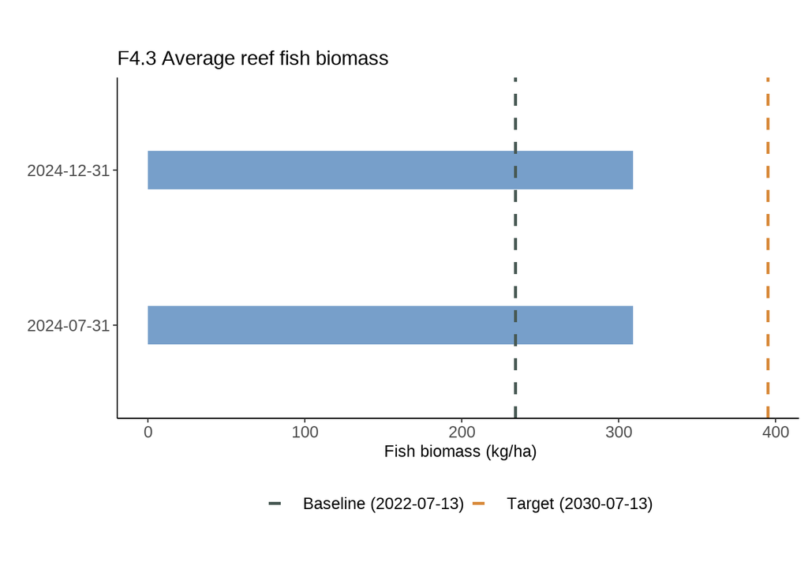

```r
#Plot for F3.1 Area of coral reef restoration
gfcrIndF4_3PlotTBL <- gfcrProjectReports$F4 %>%
  filter(`Data Type` == "Report" &
           grepl(pattern = "F4.3", x = `Sub-Indicator Name`)) %>%
  bind_rows(gfcrProjectReports$F4 %>%
              filter(`Data Type` == "Target" &
                       grepl(pattern = "F4.3", x = `Sub-Indicator Name`)) %>%
              filter(`Reporting Date` == max(`Reporting Date`))) %>%
  mutate(Color = ifelse(`Reporting Date` == min(`Reporting Date`) &
                          `Data Type` == "Report",
                        "Baseline",
                        `Data Type`)) %>%
  mutate(Color = factor(Color, levels = c("Baseline", "Target", "Report")),
         `Data Type` = factor(`Data Type`, levels = c("Target", "Report")),
         `Reporting Date` = factor(`Reporting Date`),
         Label = paste0(Color, " (", `Reporting Date`, ")"))

dataLabels = gfcrIndF4_3PlotTBL$Label
names(dataLabels) <- gfcrIndF4_3PlotTBL$Color

ggplot() +
  geom_col(data = gfcrIndF4_3PlotTBL %>%
             filter(Color == "Report"),
           aes(x = `Reporting Date`, y = Value),
           fill = "#779FCA",
           width = 0.25) +
  geom_hline(data = gfcrIndF4_3PlotTBL %>%
               filter(Color != "Report"),
             aes(yintercept = Value, color = Color),
             linetype = "dashed",
             linewidth = 1) +
  labs(x = "",
       y = expression(paste("Fish biomass (kg/ha)")),
       title = "F4.3 Average reef fish biomass") +
  scale_color_manual(values = dataColors, labels = dataLabels) +
  guides(fill = "none") +
  theme(aspect.ratio = 0.5,
        plot.title = element_text(hjust = 0, size = 25),
        panel.background = element_rect(fill = "white"),
        legend.title = element_blank(),
        legend.position = "bottom",
        axis.title = element_text(size = 20),
        axis.text = element_text(size = 20),
        legend.text = element_text(size = 20),
        axis.line = element_line(colour = "black")) +
  coord_flip()
```

## F5. Number of communities engaged in meaningful participation, co-development and capacity strengthening

```r
#Create a table with subindicators as rows
f5TableTrans <- gfcrProjectReports$F5 %>%
  mutate(Label =
           ifelse(`Reporting Date` == min(gfcrProjectReports$F5$`Reporting Date`),
                  paste0(`Reporting Date`, " Baseline"),
                  paste0(`Reporting Date`, " ", `Data Type`))) %>%
  pivot_wider(names_from = `Sub-Indicator Name`,
              values_from = Value) %>%
  select(Label, starts_with("F5")) %>%
  column_to_rownames(var = "Label") %>%
  sjmisc::rotate_df()

kable(f5TableTrans) %>%
  kable_styling(full_width = F, position = "left") %>%
  kableExtra::column_spec(1, bold = TRUE) %>%
  kableExtra::column_spec(baseline_rows+1,
                          background = dataColors["Baseline"],
                          color = "white") %>%
  kableExtra::column_spec(target_rows+1,
                          background = dataColors["Target"],
                          border_right = TRUE,
                          extra_css = "border-right: 1px solid black;") %>%
  kableExtra::column_spec(report_rows+1,
                          background = dataColors["Report"],
                          border_right = TRUE,
                          extra_css = "border-right: 1px solid black;")
```

|  | 2022-07-13 Baseline | 2023-07-13 Target | 2024-07-31 Report | 2024-12-31 Report | 2027-07-13 Target | 2030-07-13 Target |
| --- | --- | --- | --- | --- | --- | --- |
| F5.1 Number of local communities engaged in meaningful participation and co-development | 0 | 25 | 25 | 38 | 30 | 62 |
| F5.2 Number of local organizations engaged in meaningful participation and co-development | 0 | 40 | 40 | 43 | 50 | 60 |
| F5.3 Number of local scientific/research partners involved in strengthening capacity for participation and co-development | 0 | 3 | 5 | 5 | 7 | 8 |
| F5.4a Number of local practitioners trained / supported in coral reef conservation and management [men] | 0 | 6 | 6 | 10 | 17 | 20 |
| F5.4b Number of local practitioners trained / supported in coral reef conservation and management [women] | 0 | 4 | 4 | 12 | 17 | 26 |
| F5.4c Number of local practitioners trained / supported in coral reef conservation and management [youth] | 0 | 0 | 0 | 0 | 0 | 0 |
| F5.4d Number of local practitioners trained / supported in coral reef conservation and management [indigenous] | 0 | 0 | 0 | 0 | 0 | 0 |
| F5.5 Number of agreements with local authorities or fishing cooperatives to manage marine resources | 0 | 27 | 19 | 28 | 35 | 40 |
| F5.6 Number of national policies linked to GFCR engagement | 0 | 1 | 1 | 1 | 1 | 5 |

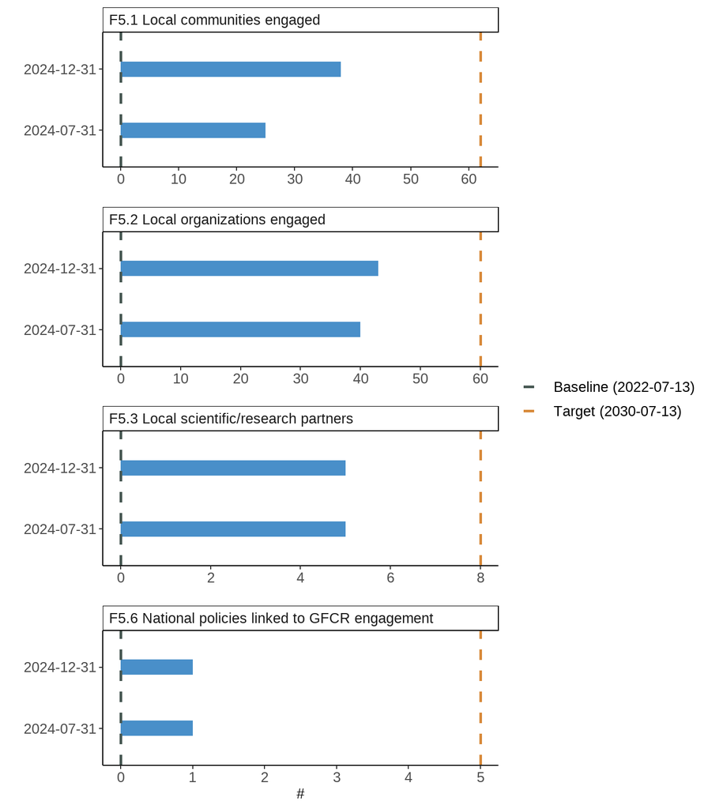

```r
#Plot for sub-indicators with number values - F5.1, F5.2, F5.3, F5.5, F5.6
gfcrIndF5_12356_PlotTBL <- gfcrProjectReports$F5 %>%
  filter(`Data Type` == "Report" &
           grepl(pattern = "F5.1|F5.2|F5.3|F3.5|F5.6",
                 x = `Sub-Indicator Name`)) %>%
  bind_rows(gfcrProjectReports$F5 %>%
              filter(`Data Type` == "Target" &
                       grepl(pattern = "F5.1|F5.2|F5.3|F3.5|F5.6",
                             x = `Sub-Indicator Name`)) %>%
              filter(`Reporting Date` == max(`Reporting Date`))) %>%
  mutate(Color = ifelse(`Reporting Date` == min(`Reporting Date`) &
                          `Data Type` == "Report",
                        "Baseline",
                        `Data Type`)) %>%
  mutate(Color = factor(Color, levels = c("Baseline", "Target", "Report")),
         `Data Type` = factor(`Data Type`, levels = c("Target", "Report")),
         `Reporting Date` = factor(`Reporting Date`),
         Label = paste0(Color, " (", `Reporting Date`, ")"),
         NumberType =
           case_when(grepl(pattern = "F5.1",
                           x = `Sub-Indicator Name`) ~
                       "F5.1 Local communities engaged",
                     grepl(pattern = "F5.2",
                           x = `Sub-Indicator Name`) ~
                       "F5.2 Local organizations engaged",
                     grepl(pattern = "F5.3",
                           x = `Sub-Indicator Name`) ~
                       "F5.3 Local scientific/research partners",
                     grepl(pattern = "F5.5",
                           x = `Sub-Indicator Name`) ~
                       "F5.5 Agreements with local authorities",
                     grepl(pattern = "F5.6",
                           x = `Sub-Indicator Name`) ~
                       "F5.6 National policies linked to GFCR engagement"))

dataLabels = gfcrIndF5_12356_PlotTBL$Label
names(dataLabels) <- gfcrIndF5_12356_PlotTBL$Color

ggplot() +
  facet_wrap(~NumberType, ncol = 1, scales = "free") +
  geom_col(data = gfcrIndF5_12356_PlotTBL %>%
             filter(Color == "Report"),
           aes(x = `Reporting Date`, y = Value, fill = Color),
           width = 0.25) +
  geom_hline(data = gfcrIndF5_12356_PlotTBL %>%
               filter(Color != "Report"),
             aes(yintercept = Value, color = Color),
             linetype = "dashed",
             linewidth = 1) +
  labs(x = "",
       y = "#") +
  scale_y_continuous(breaks = scales::pretty_breaks(n = 5),
                     labels = scales::number_format(accuracy = 1)) +
  scale_fill_manual(values = dataColors) +
  scale_color_manual(values = dataColors, labels = dataLabels) +
  guides(fill = "none") +
  theme(panel.spacing = unit(1, "lines"),
        plot.title = element_text(hjust = 0, size = 25),
        panel.background = element_rect(fill = "white"),
        legend.title = element_blank(),
        legend.position = "right",
        axis.title = element_text(size = 20),
        axis.text = element_text(size = 20),
        legend.text = element_text(size = 20),
        axis.line = element_line(colour = "black"),
        strip.background = element_rect(fill = "white", colour = "black"),
        strip.text = element_text(hjust = 0, size = 20)) +
  coord_flip()
```

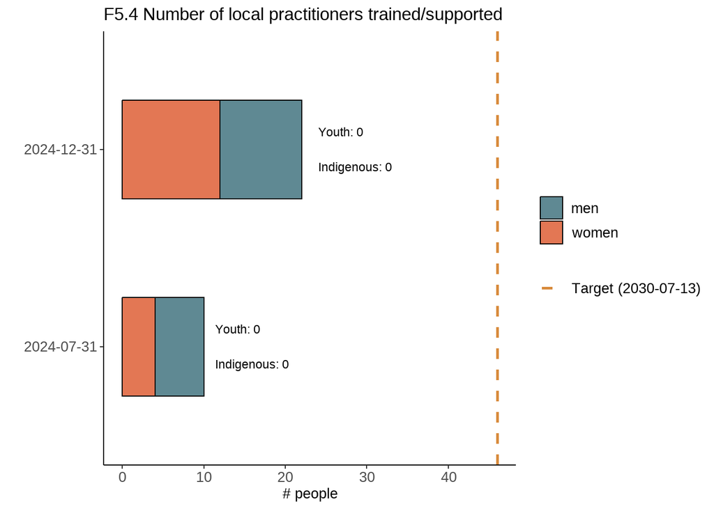

```r
##Stacked bar plot by gender with percentages of youth and indigenous as captions
populationColors <- c("#777777", "#5F8993", "#E37754", "#F6DA80", "#454C84")
names(populationColors) <- c("total", "men", "women", "youth", "indigenous")

# Extract text within brackets to get "men" and "women"
extract_text <- function(s) {
  str_extract(s, "\\[(.*?)\\]") %>%    # Extract text within square brackets
    str_replace_all("\\[|\\]", "")     # Remove brackets
}

# Prepare men/women data
gfcrIndF5_4PlotBarsTBL <- gfcrProjectReports$F5 %>%
  filter(`Data Type` == "Report" &
           grepl(pattern = "F5.4a|F5.4b",
                 x = `Sub-Indicator Name`)) %>%
  filter(`Reporting Date` != min(`Reporting Date`)) %>%
  mutate(`Reporting Date` = factor(`Reporting Date`),
         PopulationType = extract_text(`Sub-Indicator Name`)) %>%
  mutate(PopulationType = factor(PopulationType, levels = c("men", "women")))

# Prepare youth and indigenous data
gfcrIndF5_4OtherTBL <- gfcrProjectReports$F5 %>%
  filter(`Data Type` == "Report",
         grepl("F5.4c|F5.4d", `Sub-Indicator Name`)) %>%
  filter(`Reporting Date` != min(`Reporting Date`)) %>%
  mutate(`Reporting Date` = factor(`Reporting Date`),
         PopulationType = extract_text(`Sub-Indicator Name`)) %>%
  group_by(`Reporting Date`, PopulationType) %>%
  summarise(Value = sum(Value), .groups = "drop") %>%
  pivot_wider(names_from = PopulationType, values_from = Value, values_fill = 0)

# Get total height of each bar (men + women)
bar_totals <- gfcrIndF5_4PlotBarsTBL %>%
  group_by(`Reporting Date`) %>%
  summarise(Total = sum(Value), .groups = "drop")

# Combine totals with youth and indigenous
label_data <- left_join(bar_totals, gfcrIndF5_4OtherTBL, by = "Reporting Date") %>%
  mutate(Label = paste0("Youth: ", youth, "\nIndigenous: ", indigenous))

# Extract target data
gfcrIndF5_4TargetTBL <- gfcrProjectReports$F5 %>%
  filter(`Data Type` == "Target",
         grepl("F5.4a|F5.4b", `Sub-Indicator Name`)) %>%
  group_by(`Reporting Date`, `Data Type`) %>%
  summarise(TargetTotal = sum(Value), .groups = "drop") %>%
  filter(`Reporting Date` == max(`Reporting Date`))

#Horizontal stacked barplots, dashed target, and numbers for youth and indigenous
ggplot(data = gfcrIndF5_4PlotBarsTBL,
       aes(x = `Reporting Date`, y = Value, fill = PopulationType)) +
  geom_col(color = "black", width = 0.5) +
  geom_hline(data = gfcrIndF5_4TargetTBL,
             aes(yintercept = TargetTotal,
                 color = `Data Type`),
             linetype = "dashed",
             linewidth = 1) +
  geom_label(data = label_data,
           aes(x = `Reporting Date`,
               y = Total * 1.05, label = Label),
           inherit.aes = FALSE,
           size = 6, hjust = 0,
           fill = "white",    # Background color
           alpha = 0.6,       # Partial transparency
           label.size = 0,  # Border thickness
           color = "black") +  # Text color
  labs(title = "F5.4 Number of local practitioners trained/supported",
       x = "",
       y = "# people") +
  scale_fill_manual(values = populationColors) +
  scale_color_manual(values = dataColors, labels = dataLabels) +
  theme(plot.title = element_text(hjust = 0, size = 25),
        panel.background = element_rect(fill = "white"),
        legend.title = element_blank(),
        axis.title = element_text(size = 20),
        axis.text = element_text(size = 20),
        legend.text = element_text(size = 20),
        axis.line = element_line(colour = "black"),
        legend.position = "right",
        strip.text = element_text(size = 18),
        strip.background = element_blank()) +
  coord_flip(clip = "off")
```

## F6. Number of people supported through livelihoods and direct jobs

```r
#Create a table with subindicators as rows
f6TableTrans <- gfcrProjectReports$F6 %>%
  mutate(Label =
           ifelse(`Reporting Date` == min(gfcrProjectReports$F6$`Reporting Date`),
                  paste0(`Reporting Date`, " Baseline"),
                  paste0(`Reporting Date`, " ", `Data Type`))) %>%
  pivot_wider(names_from = `Sub-Indicator Name`,
              values_from = Value) %>%
  select(Label, starts_with("F6")) %>%
  column_to_rownames(var = "Label") %>%
  sjmisc::rotate_df()

kable(f6TableTrans) %>%
  kable_styling(full_width = F, position = "left") %>%
  kableExtra::column_spec(1, bold = TRUE) %>%
  kableExtra::column_spec(baseline_rows+1,
                          background = dataColors["Baseline"],
                          color = "white") %>%
  kableExtra::column_spec(target_rows+1,
                          background = dataColors["Target"],
                          border_right = TRUE,
                          extra_css = "border-right: 1px solid black;") %>%
  kableExtra::column_spec(report_rows+1,
                          background = dataColors["Report"],
                          border_right = TRUE,
                          extra_css = "border-right: 1px solid black;")
```

|  | 2022-07-13 Baseline | 2023-07-13 Target | 2024-07-31 Report | 2024-12-31 Report | 2027-07-13 Target | 2030-07-13 Target |
| --- | --- | --- | --- | --- | --- | --- |
| F6.1a Number of direct jobs created (disaggregated by gender, youth, Indigenous peoples) [men] | 0 | 12 | 42 | 612 | 170 | 500 |
| F6.1b Number of direct jobs created (disaggregated by gender, youth, Indigenous peoples) [women] | 0 | 13 | 0 | 612 | 175 | 620 |
| F6.1c Number of direct jobs created (disaggregated by gender, youth, Indigenous peoples) [youth] | 0 | 0 | 0 | 0 | 0 | 0 |
| F6.1d Number of direct jobs created (disaggregated by gender, youth, Indigenous peoples) [indigenous] | 0 | 0 | 0 | 0 | 0 | 0 |

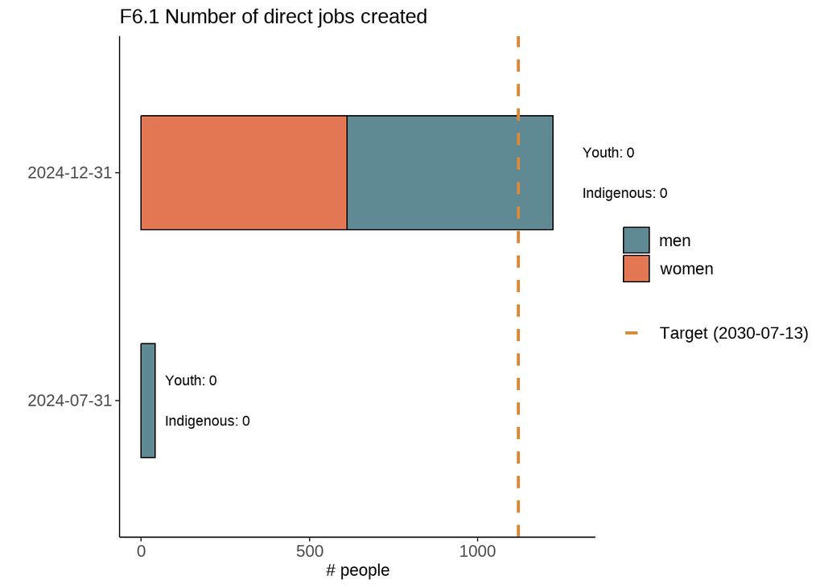

```r
##Stacked bar plot by gender with percentages of youth and indigenous as captions
populationColors <- c("#777777", "#5F8993", "#E37754", "#F6DA80", "#454C84")
names(populationColors) <- c("total", "men", "women", "youth", "indigenous")

# Extract text within brackets to get "men" and "women"
extract_text <- function(s) {
  str_extract(s, "\\[(.*?)\\]") %>%    # Extract text within square brackets
    str_replace_all("\\[|\\]", "")     # Remove brackets
}

# Prepare men/women data
gfcrIndF6PlotBarsTBL <- gfcrProjectReports$F6 %>%
  filter(`Data Type` == "Report" &
           grepl(pattern = "F6.1a|F6.1b",
                 x = `Sub-Indicator Name`)) %>%
  filter(`Reporting Date` != min(`Reporting Date`)) %>%
  mutate(`Reporting Date` = factor(`Reporting Date`),
         PopulationType = extract_text(`Sub-Indicator Name`)) %>%
  mutate(PopulationType = factor(PopulationType, levels = c("men", "women")))

# Prepare youth and indigenous data
gfcrIndF6OtherTBL <- gfcrProjectReports$F6 %>%
  filter(`Data Type` == "Report",
         grepl("F6.1c|F6.1d", `Sub-Indicator Name`)) %>%
  filter(`Reporting Date` != min(`Reporting Date`)) %>%
  mutate(`Reporting Date` = factor(`Reporting Date`),
         PopulationType = extract_text(`Sub-Indicator Name`)) %>%
  group_by(`Reporting Date`, PopulationType) %>%
  summarise(Value = sum(Value), .groups = "drop") %>%
  pivot_wider(names_from = PopulationType, values_from = Value, values_fill = 0)

# Get total height of each bar (men + women)
bar_totals <- gfcrIndF6PlotBarsTBL %>%
  group_by(`Reporting Date`) %>%
  summarise(Total = sum(Value), .groups = "drop")

# Combine totals with youth and indigenous
label_data <- left_join(bar_totals, gfcrIndF6OtherTBL, by = "Reporting Date") %>%
  mutate(Label = paste0("Youth: ", youth, "\nIndigenous: ", indigenous))

# Extract target data
gfcrIndF6TargetTBL <- gfcrProjectReports$F6 %>%
  filter(`Data Type` == "Target",
         grepl("F6.1a|F6.1b", `Sub-Indicator Name`)) %>%
  group_by(`Reporting Date`, `Data Type`) %>%
  summarise(TargetTotal = sum(Value), .groups = "drop") %>%
  filter(`Reporting Date` == max(`Reporting Date`))

#Horizontal stacked barplots, dashed target, and numbers for youth and indigenous
ggplot(data = gfcrIndF6PlotBarsTBL,
       aes(x = `Reporting Date`, y = Value, fill = PopulationType)) +
  geom_col(color = "black", width = 0.5) +
  geom_hline(data = gfcrIndF6TargetTBL,
             aes(yintercept = TargetTotal,
                 color = `Data Type`),
             linetype = "dashed",
             linewidth = 1) +
  geom_label(data = label_data,
           aes(x = `Reporting Date`,
               y = Total * 1.05, label = Label),
           inherit.aes = FALSE,
           size = 6, hjust = 0,
           fill = "white",    # Background color
           alpha = 0.6,       # Partial transparency
           label.size = 0,  # Border thickness
           color = "black") +  # Text color
  labs(title = "F6.1 Number of direct jobs created",
       x = "",
       y = "# people") +
  scale_fill_manual(values = populationColors) +
  scale_color_manual(values = dataColors, labels = dataLabels) +
  theme(plot.title = element_text(hjust = 0, size = 25),
        panel.background = element_rect(fill = "white"),
        legend.title = element_blank(),
        axis.title = element_text(size = 20),
        axis.text = element_text(size = 20),
        legend.text = element_text(size = 20),
        axis.line = element_line(colour = "black"),
        legend.position = "right",
        strip.text = element_text(size = 18),
        strip.background = element_blank()) +
  coord_flip(clip = "off")
```

## F7. Number of people supported to better adapt, respond and recover to the effects of climate change and major external shocks as a result of GFCR

```r
#Create a table with subindicators as rows
f7TableTrans <- gfcrProjectReports$F7 %>%
  mutate(Label =
           ifelse(`Reporting Date` == min(gfcrProjectReports$F7$`Reporting Date`),
                  paste0(`Reporting Date`, " Baseline"),
                  paste0(`Reporting Date`, " ", `Data Type`))) %>%
  pivot_wider(names_from = `Sub-Indicator Name`, values_from = Value) %>%
  select(Label, starts_with("F7")) %>%
  column_to_rownames(var = "Label") %>%
  sjmisc::rotate_df()

kable(f7TableTrans) %>%
  kable_styling(full_width = F, position = "left") %>%
  kableExtra::column_spec(1, bold = TRUE) %>%
  kableExtra::column_spec(baseline_rows+1,
                          background = dataColors["Baseline"],
                          color = "white") %>%
  kableExtra::column_spec(target_rows+1,
                          background = dataColors["Target"],
                          border_right = TRUE,
                          extra_css = "border-right: 1px solid black;") %>%
  kableExtra::column_spec(report_rows+1,
                          background = dataColors["Report"],
                          border_right = TRUE,
                          extra_css = "border-right: 1px solid black;")
```

|  | 2022-07-13 Baseline | 2023-07-13 Target | 2024-07-31 Report | 2024-12-31 Report | 2027-07-13 Target | 2030-07-13 Target |
| --- | --- | --- | --- | --- | --- | --- |
| F7.1a Total direct beneficiaries (disaggregated by gender, youth, Indigenous peoples) [men] | 0 | 288 | 228 | 2549 | 2175 | 3262 |
| F7.1b Total direct beneficiaries (disaggregated by gender, youth, Indigenous peoples) [women] | 0 | 250 | 310 | 2500 | 2175 | 3262 |
| F7.1c Total direct beneficiaries (disaggregated by gender, youth, Indigenous peoples) [youth] | 0 | 0 | 0 | 0 | 0 | 0 |
| F7.1d Total direct beneficiaries (disaggregated by gender, youth, Indigenous peoples) [indigenous] | 0 | 0 | 0 | 4 | 0 | 0 |
| F7.2a Total indirect beneficiaries (disaggregated by gender, youth, Indigenous peoples) [men] | 1750000 | 1750000 | 1750000 | 1750000 | 2000000 | 2150000 |
| F7.2b Total indirect beneficiaries (disaggregated by gender, youth, Indigenous peoples) [women] | 1760000 | 1760000 | 1760000 | 1750000 | 2000000 | 2150000 |
| F7.2c Total indirect beneficiaries (disaggregated by gender, youth, Indigenous peoples) [youth] | 0 | 0 | 0 | 0 | 0 | 0 |
| F7.2d Total indirect beneficiaries (disaggregated by gender, youth, Indigenous peoples) [indigenous] | 0 | 0 | 0 | 0 | 0 | 0 |
| F7.3 Number of financial mechanisms/reforms to help coastal communities respond and recover from external shocks | 0 | 0 | 0 | 0 | 1 | 3 |
| F7.4 Number of governance reforms/policies to support response and recovery to external shocks | 0 | 0 | 0 | 0 | 4 | 4 |

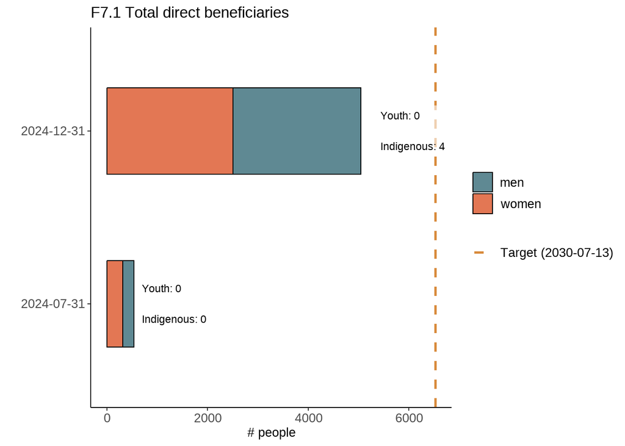

```r
##Stacked bar plot by gender with percentages of youth and indigenous as captions
populationColors <- c("#777777", "#5F8993", "#E37754", "#F6DA80", "#454C84")
names(populationColors) <- c("total", "men", "women", "youth", "indigenous")

# Extract text within brackets to get "men" and "women"
extract_text <- function(s) {
  str_extract(s, "\\[(.*?)\\]") %>%    # Extract text within square brackets
    str_replace_all("\\[|\\]", "")     # Remove brackets
}

# Prepare men/women data
gfcrIndF7_1PlotBarsTBL <- gfcrProjectReports$F7 %>%
  filter(`Data Type` == "Report" &
           grepl(pattern = "F7.1a|F7.1b",
                 x = `Sub-Indicator Name`)) %>%
  filter(`Reporting Date` != min(`Reporting Date`)) %>%
  mutate(`Reporting Date` = factor(`Reporting Date`),
         PopulationType = extract_text(`Sub-Indicator Name`)) %>%
  mutate(PopulationType = factor(PopulationType, levels = c("men", "women")))

# Prepare youth and indigenous data
gfcrIndF7_1OtherTBL <- gfcrProjectReports$F7 %>%
  filter(`Data Type` == "Report",
         grepl("F7.1c|F7.1d", `Sub-Indicator Name`)) %>%
  filter(`Reporting Date` != min(`Reporting Date`)) %>%
  mutate(`Reporting Date` = factor(`Reporting Date`),
         PopulationType = extract_text(`Sub-Indicator Name`)) %>%
  group_by(`Reporting Date`, PopulationType) %>%
  summarise(Value = sum(Value), .groups = "drop") %>%
  pivot_wider(names_from = PopulationType, values_from = Value, values_fill = 0)

# Get total height of each bar (men + women)
bar_totals <- gfcrIndF7_1PlotBarsTBL %>%
  group_by(`Reporting Date`) %>%
  summarise(Total = sum(Value), .groups = "drop")

# Combine totals with youth and indigenous
label_data <- left_join(bar_totals, gfcrIndF7_1OtherTBL, by = "Reporting Date") %>%
  mutate(Label = paste0("Youth: ", youth, "\nIndigenous: ", indigenous))

# Extract target data
gfcrIndF7_1TargetTBL <- gfcrProjectReports$F7 %>%
  filter(`Data Type` == "Target",
         grepl("F7.1a|F7.1b", `Sub-Indicator Name`)) %>%
  group_by(`Reporting Date`, `Data Type`) %>%
  summarise(TargetTotal = sum(Value), .groups = "drop") %>%
  filter(`Reporting Date` == max(`Reporting Date`))

#Horizontal stacked barplots, dashed target, and numbers for youth and indigenous
ggplot(data = gfcrIndF7_1PlotBarsTBL,
       aes(x = `Reporting Date`, y = Value, fill = PopulationType)) +
  geom_col(color = "black", width = 0.5) +
  geom_hline(data = gfcrIndF7_1TargetTBL,
             aes(yintercept = TargetTotal,
                 color = `Data Type`),
             linetype = "dashed",
             linewidth = 1) +
  geom_label(data = label_data,
           aes(x = `Reporting Date`,
               y = Total * 1.05, label = Label),
           inherit.aes = FALSE,
           size = 6, hjust = 0,
           fill = "white",    # Background color
           alpha = 0.6,       # Partial transparency
           label.size = 0,  # Border thickness
           color = "black") +  # Text color
  labs(title = "F7.1 Total direct beneficiaries",
       x = "",
       y = "# people") +
  scale_fill_manual(values = populationColors) +
  scale_color_manual(values = dataColors, labels = dataLabels) +
  theme(plot.title = element_text(hjust = 0, size = 25),
        panel.background = element_rect(fill = "white"),
        legend.title = element_blank(),
        axis.title = element_text(size = 20),
        axis.text = element_text(size = 20),
        legend.text = element_text(size = 20),
        axis.line = element_line(colour = "black"),
        legend.position = "right",
        strip.text = element_text(size = 18),
        strip.background = element_blank()) +
  coord_flip(clip = "off")
```

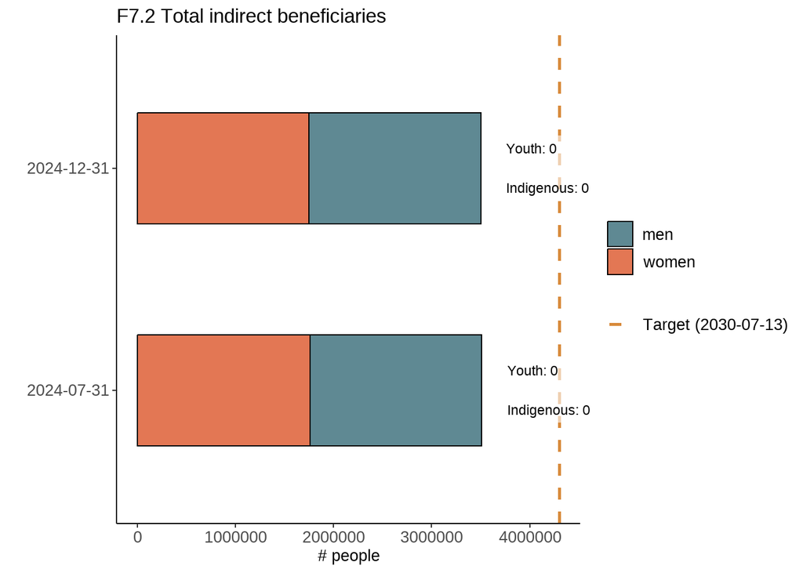

```r
##Stacked bar plot by gender with percentages of youth and indigenous as captions
populationColors <- c("#777777", "#5F8993", "#E37754", "#F6DA80", "#454C84")
names(populationColors) <- c("total", "men", "women", "youth", "indigenous")

# Extract text within brackets to get "men" and "women"
extract_text <- function(s) {
  str_extract(s, "\\[(.*?)\\]") %>%    # Extract text within square brackets
    str_replace_all("\\[|\\]", "")     # Remove brackets
}

# Prepare men/women data
gfcrIndF7_2PlotBarsTBL <- gfcrProjectReports$F7 %>%
  filter(`Data Type` == "Report" &
           grepl(pattern = "F7.2a|F7.2b",
                 x = `Sub-Indicator Name`)) %>%
  filter(`Reporting Date` != min(`Reporting Date`)) %>%
  mutate(`Reporting Date` = factor(`Reporting Date`),
         PopulationType = extract_text(`Sub-Indicator Name`)) %>%
  mutate(PopulationType = factor(PopulationType, levels = c("men", "women")))

# Prepare youth and indigenous data
gfcrIndF7_2OtherTBL <- gfcrProjectReports$F7 %>%
  filter(`Data Type` == "Report",
         grepl("F7.2c|F7.2d", `Sub-Indicator Name`)) %>%
  filter(`Reporting Date` != min(`Reporting Date`)) %>%
  mutate(`Reporting Date` = factor(`Reporting Date`),
         PopulationType = extract_text(`Sub-Indicator Name`)) %>%
  group_by(`Reporting Date`, PopulationType) %>%
  summarise(Value = sum(Value), .groups = "drop") %>%
  pivot_wider(names_from = PopulationType, values_from = Value, values_fill = 0)

# Get total height of each bar (men + women)
bar_totals <- gfcrIndF7_2PlotBarsTBL %>%
  group_by(`Reporting Date`) %>%
  summarise(Total = sum(Value), .groups = "drop")

# Combine totals with youth and indigenous
label_data <- left_join(bar_totals, gfcrIndF7_2OtherTBL, by = "Reporting Date") %>%
  mutate(Label = paste0("Youth: ", youth, "\nIndigenous: ", indigenous))

# Extract target data
gfcrIndF7_2TargetTBL <- gfcrProjectReports$F7 %>%
  filter(`Data Type` == "Target",
         grepl("F7.2a|F7.2b", `Sub-Indicator Name`)) %>%
  group_by(`Reporting Date`, `Data Type`) %>%
  summarise(TargetTotal = sum(Value), .groups = "drop") %>%
  filter(`Reporting Date` == max(`Reporting Date`))

#Horizontal stacked barplots, dashed target, and numbers for youth and indigenous
ggplot(data = gfcrIndF7_2PlotBarsTBL,
       aes(x = `Reporting Date`, y = Value, fill = PopulationType)) +
  geom_col(color = "black", width = 0.5) +
  geom_hline(data = gfcrIndF7_2TargetTBL,
             aes(yintercept = TargetTotal,
                 color = `Data Type`),
             linetype = "dashed",
             linewidth = 1) +
  geom_label(data = label_data,
           aes(x = `Reporting Date`,
               y = Total * 1.05, label = Label),
           inherit.aes = FALSE,
           size = 6, hjust = 0,
           fill = "white",    # Background color
           alpha = 0.6,       # Partial transparency
           label.size = 0,  # Border thickness
           color = "black") +  # Text color
  labs(title = "F7.2 Total indirect beneficiaries",
       x = "",
       y = "# people") +
  scale_fill_manual(values = populationColors) +
  scale_color_manual(values = dataColors, labels = dataLabels) +
  theme(plot.title = element_text(hjust = 0, size = 25),
        panel.background = element_rect(fill = "white"),
        legend.title = element_blank(),
        axis.title = element_text(size = 20),
        axis.text = element_text(size = 20),
        legend.text = element_text(size = 20),
        axis.line = element_line(colour = "black"),
        legend.position = "right",
        strip.text = element_text(size = 18),
        strip.background = element_blank()) +
  coord_flip(clip = "off")
```

```r
#Plot for sub-indicators with number values - F7.3 & F7.4
gfcrIndF7_34_PlotTBL <- gfcrProjectReports$F7 %>%
  filter(`Data Type` == "Report" &
           grepl(pattern = "F7.3|F7.4",
                 x = `Sub-Indicator Name`)) %>%
  bind_rows(gfcrProjectReports$F7 %>%
              filter(`Data Type` == "Target" &
                       grepl(pattern = "F7.3|F7.4",
                             x = `Sub-Indicator Name`)) %>%
              filter(`Reporting Date` == max(`Reporting Date`))) %>%
  mutate(Color = ifelse(`Reporting Date` == min(`Reporting Date`) &
                          `Data Type` == "Report",
                        "Baseline",
                        `Data Type`)) %>%
  mutate(Color = factor(Color, levels = c("Baseline", "Target", "Report")),
         `Data Type` = factor(`Data Type`, levels = c("Target", "Report")),
         `Reporting Date` = factor(`Reporting Date`),
         Label = paste0(Color, " (", `Reporting Date`, ")"),
         NumberType =
           case_when(grepl(pattern = "F7.3",
                           x = `Sub-Indicator Name`) ~
                       "F7.3 Financial mechanims/reforms",
                     grepl(pattern = "F7.4",
                           x = `Sub-Indicator Name`) ~
                       "F7.4 Governance reforms/policies"))

dataLabels = gfcrIndF7_34_PlotTBL$Label
names(dataLabels) <- gfcrIndF7_34_PlotTBL$Color

# ggplot() +
#   facet_wrap(~NumberType, ncol = 1, scales = "free") +
#   geom_col(data = gfcrIndF7_34_PlotTBL %>%
#              filter(Color == "Report"),
#            aes(x = `Reporting Date`, y = Value, fill = Color),
#            width = 0.25) +
#   geom_hline(data = gfcrIndF7_34_PlotTBL %>%
#                filter(Color != "Report"),
#              aes(yintercept = Value, color = Color),
#              linetype = "dashed",
#              linewidth = 1) +
#   labs(x = "",
#        y = "#") +
#   scale_y_continuous(breaks = scales::pretty_breaks(n = 5),
#                      labels = scales::number_format(accuracy = 1)) +
#   scale_fill_manual(values = dataColors) +
#   scale_color_manual(values = dataColors, labels = dataLabels) +
#   guides(fill = "none") +
#   theme(panel.spacing = unit(1, "lines"),
#         plot.title = element_text(hjust = 0, size = 25),
#         panel.background = element_rect(fill = "white"),
#         legend.title = element_blank(),
#         legend.position = "right",
#         axis.title = element_text(size = 20),
#         axis.text = element_text(size = 20),
#         legend.text = element_text(size = 20),
#         axis.line = element_line(colour = "black"),
#         strip.background = element_rect(fill = "white", colour = "black"),
#         strip.text = element_text(hjust = 0, size = 20)) +
#   coord_flip()
```

## Finance solutions

```r
#Create a table of the finance solutions
gfcrFinanceSolTBL <- gfcrProjectReports$BusinessesFinanceSolutions

kable(gfcrFinanceSolTBL) %>% kable_styling(full_width = F, position = "left") %>% kableExtra::column_spec(1, bold = TRUE)
```

| Project | Title | Reporting Date | Data Type | Business / Finance Solution | Sustainable Finance Mechanisms | Sector | Incubator Used | GFCR Funded-Incubation | Local Enterprise | Gender Smart Investment |
| --- | --- | --- | --- | --- | --- | --- | --- | --- | --- | --- |
| MAR+Invest | Mid year Report | 2024-07-31 | Report | Natoure | Sustainable livelihood mechanisms | Sustainable Coastal Development - Ecotourism | Yes | Yes | No | No |
| MAR+Invest | Mid year Report | 2024-07-31 | Report | Marketing of food macroalgae | Incubator / Technical assistance facility | Sustainable Ocean Production - Aquaculture | Yes | Yes | No | Yes |
| MAR+Invest | Mid year Report | 2024-07-31 | Report | Women of the Sea and Ecotourism in Sian Ka'an | Incubator / Technical assistance facility | Sustainable Coastal Development - Ecotourism | Yes | Yes | No | No |
| MAR+Invest | Mid year Report | 2024-07-31 | Report | Educational monitoring of reef systems (Medusa) | Incubator / Technical assistance facility | Sustainable Coastal Development - Coral Restoration Revenue Models | Yes | Yes | No | No |
| MAR+Invest | Mid year Report | 2024-07-31 | Report | Tourism entreprises to rebuild coral reefs in Roatán | Incubator / Technical assistance facility | Sustainable Coastal Development - Coral Restoration Revenue Models | Yes | Yes | No | Yes |
| MAR+Invest | Mid year Report | 2024-07-31 | Report | Go Blue | Incubator / Technical assistance facility | Sustainable Coastal Development - Ecotourism | Yes | Yes | No | Yes |
| MAR+Invest | Mid year Report | 2024-07-31 | Report | Coral restoration regenerative tourism strategy in Akumal | Incubator / Technical assistance facility | Sustainable Coastal Development - Coral Restoration Revenue Models | Yes | Yes | No | No |
| MAR+Invest | Mid year Report | 2024-07-31 | Report | Sustainable financing for the management of protected areas through a test laboratory | Incubator / Technical assistance facility | Circular Economy and Pollution Management - Waste Management | Yes | Yes | No | No |
| MAR+Invest | Mid year Report | 2024-07-31 | Report | Lionfish Jewelry Market | Incubator / Technical assistance facility | Sustainable Ocean Production - Other | Yes | Yes | No | Yes |
| MAR+Invest | Mid year Report | 2024-07-31 | Report | Beaches without sargassum | Incubator / Technical assistance facility | Sustainable Ocean Production - Other | Yes | Yes | No | No |
| MAR+Invest | Mid year Report | 2024-07-31 | Report | Recycling and valuation of waste to promote a circular economy | Incubator / Technical assistance facility | Circular Economy and Pollution Management - Waste Management | Yes | Yes | No | Yes |
| MAR+Invest | Mid year Report | 2024-07-31 | Report | Connecting coastal marine ecosystem services with innovative markets as a comprehensive strategy to preserve the health of the Mesoamerican Reef System | Incubator / Technical assistance facility | Financial Mechanisms - Other | Yes | Yes | No | Yes |
| MAR+Invest | Mid year Report | 2024-07-31 | Report | Community Restoration of Coral Reef in Puerto Morelos (Marine Interpretive Trails: Creating Life for Conservation and Ecotourism in the MAR) | Incubator / Technical assistance facility | Sustainable Coastal Development - Ecotourism | Yes | Yes | No | No |
| MAR+Invest | Mid year Report | 2024-07-31 | Report | King Crab Restorative Mariaculture | Incubator / Technical assistance facility | Sustainable Ocean Production - Aquaculture | Yes | Yes | No | Yes |
| MAR+Invest | Mid year Report | 2024-07-31 | Report | Artificial Wetlands | Incubator / Technical assistance facility | Circular Economy and Pollution Management - Waste Management | Yes | Yes | No | No |
| MAR+Invest | Mid year Report | 2024-07-31 | Report | Thalasso | Incubator / Technical assistance facility | Sustainable Ocean Production - Other | Yes | Yes | No | No |
| MAR+Invest | Mid year Report | 2024-07-31 | Report | Aquosmic | Incubator / Technical assistance facility | Circular Economy and Pollution Management - Waste Management | NA | No | No | No |
| MAR+Invest | Mid year Report | 2024-07-31 | Report | Tela Marine | NA | Sustainable Ocean Production - Other | Yes | Yes | No | No |
| MAR+Invest | Mid year Report | 2024-07-31 | Report | Sarteneja Alliance for Conservation and Development | Incubator / Technical assistance facility | Sustainable Ocean Production - Other | Yes | Yes | Yes | Yes |
| MAR+Invest | Mid year Report | 2024-07-31 | Report | Tobacco Caye Marine Station | Incubator / Technical assistance facility | Sustainable Ocean Production - Other | Yes | Yes | No | No |
| MAR+Invest | Mid year Report | 2024-07-31 | Report | BioPlaster Inc | Incubator / Technical assistance facility | Sustainable Ocean Production - Other | Yes | Yes | No | No |
| MAR+Invest | Mid year Report | 2024-07-31 | Report | The Chilam Group | Incubator / Technical assistance facility | Sustainable Coastal Development - Ecotourism | Yes | Yes | No | No |
| MAR+Invest | Mid year Report | 2024-07-31 | Report | Royal Mayan Shrimp Farms | Incubator / Technical assistance facility | Sustainable Ocean Production - Aquaculture | Yes | No | Yes | No |
| MAR+Invest | Mid year Report | 2024-07-31 | Report | Reefy | Incubator / Technical assistance facility | Sustainable Coastal Development - Coastal Infrastructure | Yes | Yes | No | No |
| MAR+Invest | Mid year Report | 2024-07-31 | Report | Pescadata | Incubator / Technical assistance facility | Sustainable Ocean Production - Fisheries | Yes | Yes | No | No |
| MAR+Invest | Mid year Report | 2024-07-31 | Report | Carbonwave | Incubator / Technical assistance facility | Sustainable Ocean Production - Other | Yes | Yes | Yes | No |
| MAR+Invest | End year Report | 2024-12-31 | Report | Artificial Wetlands | Incubator / Technical assistance facility | Circular Economy and Pollution Management - Waste Management | Yes | Yes | Yes | No |
| MAR+Invest | End year Report | 2024-12-31 | Report | Beaches without sargassum | Incubator / Technical assistance facility | Sustainable Ocean Production - Other | Yes | Yes | No | No |
| MAR+Invest | End year Report | 2024-12-31 | Report | Community Restoration of Coral Reef in Puerto Morelos (Marine Interpretive Trails: Creating Life for Conservation and Ecotourism in the MAR) | Incubator / Technical assistance facility | Sustainable Coastal Development - Ecotourism | Yes | Yes | Yes | Yes |
| MAR+Invest | End year Report | 2024-12-31 | Report | Connecting coastal marine ecosystem services with innovative markets as a comprehensive strategy to preserve the health of the Mesoamerican Reef System | Incubator / Technical assistance facility | Financial Mechanisms - Other | Yes | Yes | Yes | Yes |
| MAR+Invest | End year Report | 2024-12-31 | Report | Coral restoration regenerative tourism strategy in Akumal | Incubator / Technical assistance facility | Sustainable Coastal Development - Coral Restoration Revenue Models | Yes | Yes | Yes | No |
| MAR+Invest | End year Report | 2024-12-31 | Report | Educational monitoring of reef systems (Medusa) | Incubator / Technical assistance facility | Sustainable Coastal Development - Coral Restoration Revenue Models | Yes | Yes | No | No |
| MAR+Invest | End year Report | 2024-12-31 | Report | Go Blue | Incubator / Technical assistance facility | Sustainable Coastal Development - Ecotourism | Yes | Yes | No | Yes |
| MAR+Invest | End year Report | 2024-12-31 | Report | King Crab Restorative Mariaculture | Incubator / Technical assistance facility | Sustainable Ocean Production - Aquaculture | Yes | Yes | Yes | Yes |
| MAR+Invest | End year Report | 2024-12-31 | Report | Lionfish Jewelry Market | Incubator / Technical assistance facility | Sustainable Ocean Production - Other | Yes | Yes | No | Yes |
| MAR+Invest | End year Report | 2024-12-31 | Report | Marketing of food macroalgae | Incubator / Technical assistance facility | Sustainable Ocean Production - Aquaculture | Yes | Yes | No | No |
| MAR+Invest | End year Report | 2024-12-31 | Report | Recycling and valuation of waste to promote a circular economy | Incubator / Technical assistance facility | Circular Economy and Pollution Management - Waste Management | Yes | Yes | No | Yes |
| MAR+Invest | End year Report | 2024-12-31 | Report | Sustainable financing for the management of protected areas through a test laboratory | Incubator / Technical assistance facility | Circular Economy and Pollution Management - Waste Management | Yes | Yes | Yes | No |
| MAR+Invest | End year Report | 2024-12-31 | Report | Tourism entreprises to rebuild coral reefs in Roatán | Incubator / Technical assistance facility | Sustainable Coastal Development - Coral Restoration Revenue Models | Yes | Yes | No | Yes |
| MAR+Invest | End year Report | 2024-12-31 | Report | Women of the Sea and Ecotourism in Sian Ka'an | Incubator / Technical assistance facility | Sustainable Coastal Development - Ecotourism | Yes | Yes | Yes | Yes |
| MAR+Invest | End year Report | 2024-12-31 | Report | Thalasso | Incubator / Technical assistance facility | Sustainable Ocean Production - Other | Yes | Yes | Yes | Yes |
| MAR+Invest | End year Report | 2024-12-31 | Report | Aquosmic | Incubator / Technical assistance facility | Sustainable Coastal Development - Other | Yes | Yes | Yes | Yes |
| MAR+Invest | End year Report | 2024-12-31 | Report | Sarteneja Alliance for Conservation and Development | Incubator / Technical assistance facility | Sustainable Ocean Production - Other | Yes | Yes | Yes | No |
| MAR+Invest | End year Report | 2024-12-31 | Report | Tela Marine | Incubator / Technical assistance facility | Sustainable Ocean Production - Other | Yes | Yes | Yes | No |
| MAR+Invest | End year Report | 2024-12-31 | Report | The Chilam Group | Incubator / Technical assistance facility | Sustainable Coastal Development - Ecotourism | Yes | Yes | Yes | No |
| MAR+Invest | End year Report | 2024-12-31 | Report | Bioplaster Inc | Incubator / Technical assistance facility | Sustainable Ocean Production - Other | Yes | Yes | Yes | No |
| MAR+Invest | End year Report | 2024-12-31 | Report | VOS Honduras | Incubator / Technical assistance facility | Sustainable Ocean Production - Fisheries | Yes | Yes | Yes | Yes |
| MAR+Invest | End year Report | 2024-12-31 | Report | Tobacco Caye Marine Station | Incubator / Technical assistance facility | Sustainable Ocean Production - Other | Yes | Yes | Yes | No |
| MAR+Invest | End year Report | 2024-12-31 | Report | Natoure | Incubator / Technical assistance facility | Sustainable Coastal Development - Ecotourism | Yes | Yes | Yes | No |
| MAR+Invest | End year Report | 2024-12-31 | Report | POLO'S Water Association | Incubator / Technical assistance facility | Circular Economy and Pollution Management - Waste Management | Yes | Yes | Yes | No |
| MAR+Invest | End year Report | 2024-12-31 | Report | Escuela Itinerante de Aguas y Artes | Incubator / Technical assistance facility | Sustainable Coastal Development - Other | Yes | Yes | No | Yes |
| MAR+Invest | End year Report | 2024-12-31 | Report | Mexico Circula | Incubator / Technical assistance facility | Circular Economy and Pollution Management - Waste Management | Yes | Yes | Yes | Yes |
| MAR+Invest | End year Report | 2024-12-31 | Report | Roatan Marine Park | Incubator / Technical assistance facility | Sustainable Ocean Production - Other | Yes | Yes | No | Yes |
| MAR+Invest | End year Report | 2024-12-31 | Report | FUNDAECO | Incubator / Technical assistance facility | Sustainable Coastal Development - Ecotourism | Yes | Yes | Yes | No |
| MAR+Invest | End year Report | 2024-12-31 | Report | Terminator Water Solutions | Incubator / Technical assistance facility | Circular Economy and Pollution Management - Waste Management | Yes | Yes | Yes | Yes |
| MAR+Invest | End year Report | 2024-12-31 | Report | Maritime Procurement Services | Incubator / Technical assistance facility | Sustainable Coastal Development - Coastal Infrastructure | Yes | Yes | Yes | No |
| MAR+Invest | End year Report | 2024-12-31 | Report | Royal Mayan Shrimp Farms | Incubator / Technical assistance facility | Sustainable Ocean Production - Aquaculture | Yes | Yes | Yes | No |
| MAR+Invest | End year Report | 2024-12-31 | Report | Carbonwave | Incubator / Technical assistance facility | Sustainable Ocean Production - Other | Yes | Yes | Yes | No |
| MAR+Invest | End year Report | 2024-12-31 | Report | Reefy | Incubator / Technical assistance facility | Sustainable Coastal Development - Coastal Infrastructure | Yes | Yes | No | No |

## Investments

```r
#Create a table of the investments
gfcrInvestmentsTBL <- gfcrProjectReports$Investments

kable(gfcrInvestmentsTBL) %>% kable_styling(full_width = F, position = "left") %>% kableExtra::column_spec(1, bold = TRUE)
```

| Project | Title | Reporting Date | Data Type | Business / Finance Solution | Sustainable Finance Mechanisms | Sector | Investment Source | Investment Type | Investment Amount |
| --- | --- | --- | --- | --- | --- | --- | --- | --- | --- |
| MAR+Invest | Mid year Report | 2024-07-31 | Report | Thalasso | Incubator / Technical assistance facility | Sustainable Ocean Production - Other | Private | Grant | 100000 |
| MAR+Invest | Mid year Report | 2024-07-31 | Report | Royal Mayan Shrimp Farms | Incubator / Technical assistance facility | Sustainable Ocean Production - Aquaculture | Public | Commercial loan | 300000 |
| MAR+Invest | Mid year Report | 2024-07-31 | Report | Carbonwave | Incubator / Technical assistance facility | Sustainable Ocean Production - Other | Private | Equity | 6000000 |
| MAR+Invest | End year Report | 2024-12-31 | Report | Thalasso | Incubator / Technical assistance facility | Sustainable Ocean Production - Other | Private | Grant | 100000 |
| MAR+Invest | End year Report | 2024-12-31 | Report | Bioplaster Inc | Incubator / Technical assistance facility | Sustainable Ocean Production - Other | Private | Equity | 15000 |
| MAR+Invest | End year Report | 2024-12-31 | Report | Terminator Water Solutions | Incubator / Technical assistance facility | Circular Economy and Pollution Management - Waste Management | GFCR | Concessional loan | 100000 |
| MAR+Invest | End year Report | 2024-12-31 | Report | Maritime Procurement Services | Incubator / Technical assistance facility | Sustainable Coastal Development - Coastal Infrastructure | Private | Commercial loan | 500000 |
| MAR+Invest | End year Report | 2024-12-31 | Report | Royal Mayan Shrimp Farms | Incubator / Technical assistance facility | Sustainable Ocean Production - Aquaculture | Public | Public budget | 300000 |
| MAR+Invest | End year Report | 2024-12-31 | Report | Royal Mayan Shrimp Farms | Incubator / Technical assistance facility | Sustainable Ocean Production - Aquaculture | Public | Commercial loan | 3500000 |
| MAR+Invest | End year Report | 2024-12-31 | Report | Carbonwave | Incubator / Technical assistance facility | Sustainable Ocean Production - Other | Private | Equity | 6000000 |
| MAR+Invest | End year Report | 2024-12-31 | Report | Reefy | Incubator / Technical assistance facility | Sustainable Coastal Development - Coastal Infrastructure | Private | Equity | 400000 |

## Revenue

```r
#Create a table of the revenue
gfcrRevenueTBL <- gfcrProjectReports$Revenues

kable(gfcrRevenueTBL) %>% kable_styling(full_width = F, position = "left") %>% kableExtra::column_spec(1, bold = TRUE)
```

| Project | Title | Reporting Date | Data Type | Business / Finance Solution | Sustainable Finance Mechanisms | Sector | Revenue Type | Sustainable Revenue Source | Revenue Amount |
| --- | --- | --- | --- | --- | --- | --- | --- | --- | --- |
| MAR+Invest | Mid year Report | 2024-07-31 | Report | Royal Mayan Shrimp Farms | Incubator / Technical assistance facility | Sustainable Ocean Production - Aquaculture | Natural resource sales (e.g., fisheries or aquaculture) | No | 555063 |
| MAR+Invest | Mid year Report | 2024-07-31 | Report | Carbonwave | Incubator / Technical assistance facility | Sustainable Ocean Production - Other | Natural resource sales (e.g., fisheries or aquaculture) | Yes | 5205515 |
| MAR+Invest | End year Report | 2024-12-31 | Report | Maritime Procurement Services | Incubator / Technical assistance facility | Sustainable Coastal Development - Coastal Infrastructure | Misc. revenue streams | Yes | 8233076 |
| MAR+Invest | End year Report | 2024-12-31 | Report | Royal Mayan Shrimp Farms | Incubator / Technical assistance facility | Sustainable Ocean Production - Aquaculture | Misc. revenue streams | Yes | 555063 |
| MAR+Invest | End year Report | 2024-12-31 | Report | Carbonwave | Incubator / Technical assistance facility | Sustainable Ocean Production - Other | Natural resource sales (e.g., fisheries or aquaculture) | Yes | 5205515 |

Powered by

[figure not shown]